# FinalProj

Adam Walters, Jijun Niu

2026-05-10

## Set up: Clean Data

# Part 1: Multiple Linear Regression

### Implements linear regression model

$ORtg = \beta_0 + \beta_1(USG\%) + \beta_2(TS\%) + \beta_3(TO\%) + \epsilon$

```r
# Multiple linear regression based on cleaned data
regression_model <- lm(ORtg ~ USG. + TS. + TO., data = cleaned_data)

# Storing summary of outputs determined via regression model
model_summary <- summary(regression_model)

# Storing the coefficient table
coef_table <- coef(model_summary)

# Storing confidence intervals
coef_intervals <- confint(regression_model)

#MULTIPLE LINEAR REGRESSION RESULTS

#Regression equation coefficients:
print(round(coef(regression_model), 4))
```

```
## (Intercept)        USG.         TS.         TO.
##     53.4961     -0.4189    137.4049     -0.6008
```

```r
#nRegression equation:
cat("Predicted ORtg = ",
    round(coef(regression_model)[1], 4), " + ",
    round(coef(regression_model)["USG."], 4), "(USG.) + ",
    round(coef(regression_model)["TS."], 4), "(TS.) + ",
    round(coef(regression_model)["TO."], 4), "(TO.)\n",
    sep = "")
```

```
## Predicted ORtg = 53.4961 + -0.4189(USG.) + 137.4049(TS.) + -0.6008(TO.)
```

```r
# Printing regression equation coefficients
#Coefficient table:
print(round(coef_table, 4))
```

```
##             Estimate Std. Error  t value Pr(>|t|)
## (Intercept)  53.4961     1.9706  27.1477        0
## USG.         -0.4189     0.0423  -9.8958        0
## TS.         137.4049     2.9529  46.5320        0
## TO.          -0.6008     0.0420 -14.3073        0
```

```r
# Printing adjusted R^2
#Adjusted R-squared:
cat(round(model_summary$adj.r.squared, 4), "\n")
```

```
## 0.8019
```

```r
# Printing p-values for intercept and predictors
#P-values:
print(coef_table[, "Pr(>|t|)"])
```

```
##   (Intercept)          USG.           TS.           TO.
## 1.072936e-106  1.689097e-21 7.001882e-202  3.379383e-40
```

```r
# Confidence intervals for determined coefficients
#95% confidence intervals for coefficients:
print(round(coef_intervals, 4))
```

```
##                2.5 %   97.5 %
## (Intercept)  49.6261  57.3661
## USG.         -0.5021  -0.3358
## TS.         131.6056 143.2041
## TO.          -0.6833  -0.5184
```

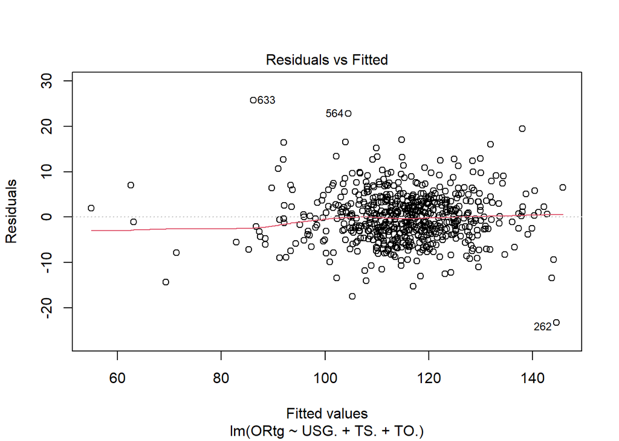

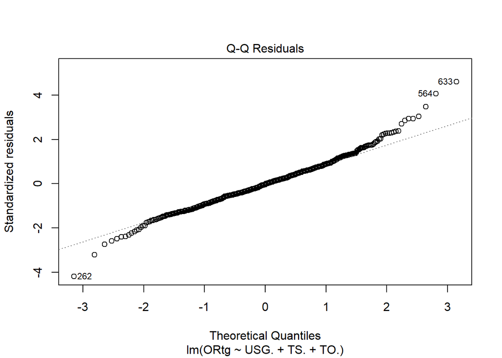

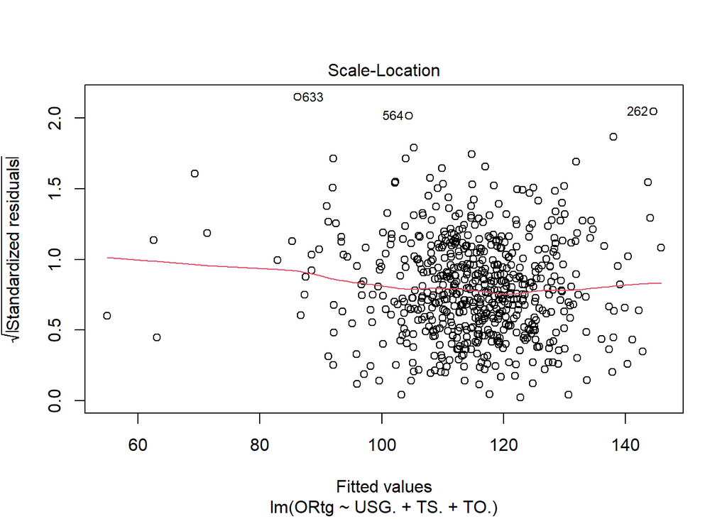

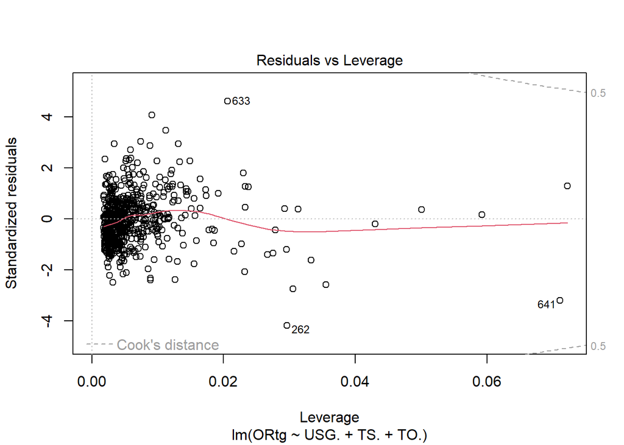

```r
# Plot model
plot(regression_model)
```

# Part 2:Hypothesis Testing: Permutation test

```r
# Define groups
high_usage <- cleaned_data$TS.[cleaned_data$USG. > 25]
low_usage <- cleaned_data$TS.[cleaned_data$USG. <= 25]

# Observed difference
obs_diff <- mean(high_usage) - mean(low_usage)

# Permutation Test
set.seed(4714)

n_permutations <- 10000
perm_diffs <- numeric(n_permutations)
all_ts <- c(high_usage, low_usage)
n_high <- length(high_usage)

for (i in 1:n_permutations) {
  shuffled <- sample(all_ts)
  perm_high <- shuffled[1:n_high]
  perm_low <- shuffled[(n_high + 1):length(all_ts)]
  perm_diffs[i] <- mean(perm_high) - mean(perm_low)
}

# Calculate P-value (two-tailed)
p_value <- mean(abs(perm_diffs) >= abs(obs_diff))
print(paste("Permutation P-value:", p_value))
```

```
## [1] "Permutation P-value: 0.0472"
```

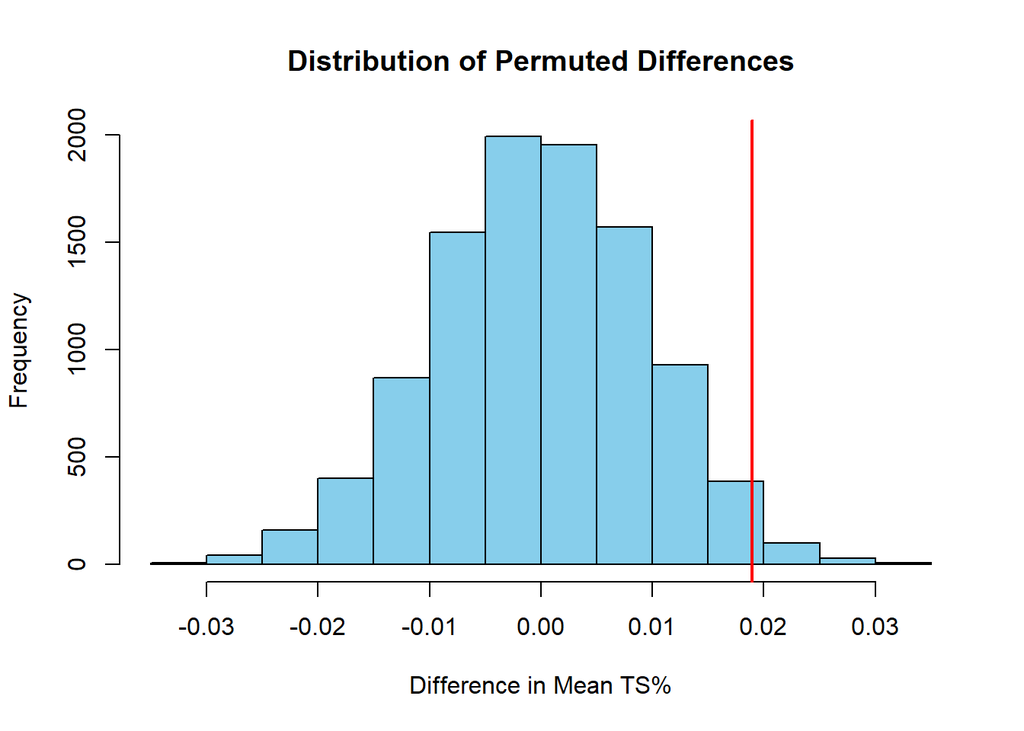

```r
# Visualize the distribution
hist(perm_diffs, main="Distribution of Permuted Differences",
     xlab="Difference in Mean TS%", col="skyblue")
abline(v = obs_diff, col="red", lwd=2)
```

# Part 3: Discrete Distribution (geometric)

We will model the number of shot attempts required for a player to achieve their first successful score using a geometric distribution. The success probability p will be approximated by TS%. We will compute expected values $ E[X]=1/p$ and probabilities such as $ P(X>k) $to compare consistency between players with different usage levels. Modeling number of attempts to first score using TS% as the probability of success $p$

step 1: use $E[x] = 1/p = 1/ ts% $ to find the mean value of the number of shot attempt a player need to achieve their first successful score

ctrl+ shift+ c –> comment multiple lines

```r
#high usage rate
expected_value_h <- mean (1/high_usage)
expected_value_h
```

```
## [1] 1.722965
```

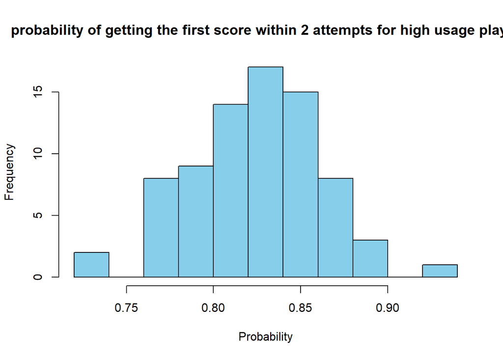

```r
k  <- 2
success_less_than_2_h <- pgeom(k-1,high_usage)
hist(success_less_than_2_h, main="probability of getting the first score within 2 attempts for high usage player", xlab="Probability", col="skyblue")
```

```r
# low usage rate
expected_value_l <- mean (1/low_usage)
expected_value_l
```

```
## [1] 1.818077
```

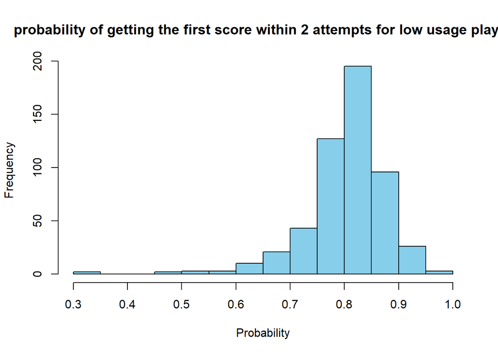

```r
success_less_than_2_l <- pgeom(k-1,low_usage)
hist(success_less_than_2_l, main="probability of getting the first score within 2 attempts for low usage player", xlab="Probability", col="skyblue")
```

Discussion: High-usage players and low-usage players have a similar mean value of around 1.75 attempts to achieve their first successful score. However, the probability of scoring within the first two attempts differs between the two groups. Low-usage players show a much wider spread, with probabilities ranging from 0.30 to 1.00, while high-usage players are more concentrated between 0.70 and 0.95. This suggests that high-usage players are generally more consistent scorers